# Cyclistic Data Analytics

Sathyam A

2023-10-30

**Scenario :** In 2016, Cyclistic launched a successful bike-share offering. Since then, the program has grown to a fleet of 5,824 bicycles that are geotracked and locked into a network of 692 stations across Chicago. The bikes can be unlocked from one station and returned to any other station in the system anytime. Until now, Cyclistic’s marketing strategy relied on building general awareness and appealing to broad consumer segments. One 2 approach that helped make these things possible was the flexibility of its pricing plans: single-ride passes, full-day passes, and annual memberships. Customers who purchase single-ride or full-day passes are referred to as casual riders. Customers who purchase annual memberships are Cyclistic members.

**Our task here is to give all the answers of the questions that have been asked by the Director**

# Ask

💡 **MARKETING TASK:** Three questions will guide the future marketing program:

1. How do annual members and casual riders use Cyclistic bikes differently?
2. Why would casual riders buy Cyclistic annual memberships?
3. How can Cyclistic use digital media to influence casual riders to become members?

# Prepare

1. Contains accurate, complete and unbiased info on Cyclistic’s historical bike trips.
2. The data is from the past 6 months. It is current and relevant to the task which has been given
3. These sources are publicly available as given in the link and the data is provided by Cyclistic

**Importing the necessary packages for the further analysis**

```r
library(tidyverse)
```

```r
library(dplyr)
library(ggplot2)
```

```r
library(skimr)
library(janitor)
library(lubridate)
library(readr)
library(ggmap)
```

**Importing the data sets of 6 months**

```r
jan <- read_csv("C:\\Users\\Admin\\Desktop\\202301-divvy-tripdata.csv")
feb <- read_csv("C:\\Users\\Admin\\Desktop\\202302-divvy-tripdata.csv")
mar <- read_csv("C:\\Users\\Admin\\Desktop\\202303-divvy-tripdata.csv")
apr <- read_csv("C:\\Users\\Admin\\Desktop\\202304-divvy-tripdata.csv")
may <- read_csv("C:\\Users\\Admin\\Desktop\\202305-divvy-tripdata.csv")
june <- read_csv("C:\\Users\\Admin\\Desktop\\202306-divvy-tripdata.csv")
```

# Process

**Binding the Data together so that we can analyze it together**

```r
trip <- rbind(jan, feb, mar, apr, may, june)
```

Notice here one thing that started_at and ended_at attributes are in the form of characters but since these are the date attributes we have to change the format from character to DATE

```r
trip$started_at = strptime(trip$started_at,"%Y-%m-%d %H:%M:%S")
trip$ended_at = strptime(trip$ended_at,"%Y-%m-%d %H:%M:%S")
```

```r
trip<-mutate(trip,tripduration=difftime(ended_at,started_at, units = "secs"))
```

**Let’s check out the data**

```r
head(trip)
```

```
## # A tibble: 6 × 14
##   ride_id          rideable_type started_at          ended_at
##   <chr>            <chr>         <dttm>              <dttm>
## 1 F96D5A74A3E41399 electric_bike 2023-01-21 20:05:42 2023-01-21 20:16:33
## 2 13CB7EB698CEDB88 classic_bike  2023-01-10 15:37:36 2023-01-10 15:46:05
## 3 BD88A2E670661CE5 electric_bike 2023-01-02 07:51:57 2023-01-02 08:05:11
## 4 C90792D034FED968 classic_bike  2023-01-22 10:52:58 2023-01-22 11:01:44
## 5 3397017529188E8A classic_bike  2023-01-12 13:58:01 2023-01-12 14:13:20
## 6 58E68156DAE3E311 electric_bike 2023-01-31 07:18:03 2023-01-31 07:21:16
## # ℹ 10 more variables: start_station_name <chr>, start_station_id <chr>,
## #   end_station_name <chr>, end_station_id <chr>, start_lat <dbl>,
## #   start_lng <dbl>, end_lat <dbl>, end_lng <dbl>, member_casual <chr>,
## #   tripduration <drtn>
```

```r
glimpse(trip)
```

```
## Rows: 2,390,459
## Columns: 14
## $ ride_id            <chr> "F96D5A74A3E41399", "13CB7EB698CEDB88", "BD88A2E670…
## $ rideable_type      <chr> "electric_bike", "classic_bike", "electric_bike", "…
## $ started_at         <dttm> 2023-01-21 20:05:42, 2023-01-10 15:37:36, 2023-01-…
## $ ended_at           <dttm> 2023-01-21 20:16:33, 2023-01-10 15:46:05, 2023-01-…
## $ start_station_name <chr> "Lincoln Ave & Fullerton Ave", "Kimbark Ave & 53rd …
## $ start_station_id   <chr> "TA1309000058", "TA1309000037", "RP-005", "TA130900…
## $ end_station_name   <chr> "Hampden Ct & Diversey Ave", "Greenwood Ave & 47th …
## $ end_station_id     <chr> "202480.0", "TA1308000002", "599", "TA1308000002", …
## $ start_lat          <dbl> 41.92407, 41.79957, 42.00857, 41.79957, 41.79957, 4…
## $ start_lng          <dbl> -87.64628, -87.59475, -87.69048, -87.59475, -87.594…
## $ end_lat            <dbl> 41.93000, 41.80983, 42.03974, 41.80983, 41.80983, 4…
## $ end_lng            <dbl> -87.64000, -87.59938, -87.69941, -87.59938, -87.599…
## $ member_casual      <chr> "member", "member", "casual", "member", "member", "…
## $ tripduration       <drtn> 651 secs, 509 secs, 794 secs, 526 secs, 919 secs, …
```

Viewing Trip data we find a lot of values less than zero.So we keep everything greater than 0

```r
trip <- filter(trip,trip$tripduration>0)
```

```r
glimpse(trip)
```

```
## Rows: 2,390,225
## Columns: 14
## $ ride_id            <chr> "F96D5A74A3E41399", "13CB7EB698CEDB88", "BD88A2E670…
## $ rideable_type      <chr> "electric_bike", "classic_bike", "electric_bike", "…
## $ started_at         <dttm> 2023-01-21 20:05:42, 2023-01-10 15:37:36, 2023-01-…
## $ ended_at           <dttm> 2023-01-21 20:16:33, 2023-01-10 15:46:05, 2023-01-…
## $ start_station_name <chr> "Lincoln Ave & Fullerton Ave", "Kimbark Ave & 53rd …
## $ start_station_id   <chr> "TA1309000058", "TA1309000037", "RP-005", "TA130900…
## $ end_station_name   <chr> "Hampden Ct & Diversey Ave", "Greenwood Ave & 47th …
## $ end_station_id     <chr> "202480.0", "TA1308000002", "599", "TA1308000002", …
## $ start_lat          <dbl> 41.92407, 41.79957, 42.00857, 41.79957, 41.79957, 4…
## $ start_lng          <dbl> -87.64628, -87.59475, -87.69048, -87.59475, -87.594…
## $ end_lat            <dbl> 41.93000, 41.80983, 42.03974, 41.80983, 41.80983, 4…
## $ end_lng            <dbl> -87.64000, -87.59938, -87.69941, -87.59938, -87.599…
## $ member_casual      <chr> "member", "member", "casual", "member", "member", "…
## $ tripduration       <drtn> 651 secs, 509 secs, 794 secs, 526 secs, 919 secs, …
```

**We have a lot of left out spaces , this makes our data inconsistent so we remove these null values**

```r
trip<-trip %>%
  na.omit()
```

**Make different columns for Date, Day, Month, Year to make things easier**

```r
trip$date<-as.Date(trip$started_at)
trip$month<-format(as.Date(trip$started_at),"%m")
trip$day<-format(as.Date(trip$started_at),"%d")
trip$year<-format(as.Date(trip$started_at),"%y")
trip$day_of_week<-format(as.Date(trip$started_at),"%A")
```

# Analyze

Here will be performing calculations on the data and identification of trends, patterns and relationships as well as statistical analysis by calculating mean, median, maximum and minimum on ride length column for both casual riders and members

```r
trip %>%
  group_by(member_casual) %>% summarise(average_trip_duration=mean(tripduration),median_duration=median(tripduration),max_trip_duration=max(tripduration),min_trip_duration=min(tripduration))
```

```
## # A tibble: 2 × 5
##   member_casual average_trip_duration median_duration max_trip_duration
##   <chr>         <drtn>                <drtn>          <drtn>
## 1 casual        1356.2626 secs        751 secs        728178 secs
## 2 member         705.0431 secs        500 secs         89872 secs
## # ℹ 1 more variable: min_trip_duration <drtn>
```

```r
# Total number of rides
trip %>%
  group_by(member_casual) %>%
  summarise(ride_count=length(ride_id))
```

```
## # A tibble: 2 × 2
##   member_casual ride_count
##   <chr>              <int>
## 1 casual            616503
## 2 member           1203829
```

```r
breaks<-hour((hm("00:00", "6:00", "12:00", "18:00", "23:59")))

labels <- c("Night", "Morning", "Afternoon", "Evening")
```

```r
trip$time_of_the_trip <-cut(x=hour(trip$started_at), breaks = breaks, labels = labels, include.lowest = "true")
```

```r
# Comparing Ride Lengths between different Times of the Day
trip %>%
  group_by(member_casual,time_of_the_trip) %>%
  summarise(number_of_rides=n(),average_trip_duration=mean(tripduration),.groups = "drop")
```

```
## # A tibble: 8 × 4
##   member_casual time_of_the_trip number_of_rides average_trip_duration
##   <chr>         <fct>                      <int> <drtn>
## 1 casual        Night                      34131 1111.4051 secs
## 2 casual        Morning                   156908 1377.0859 secs
## 3 casual        Afternoon                 309012 1420.2837 secs
## 4 casual        Evening                   116452 1230.0872 secs
## 5 member        Night                      71479  614.3502 secs
## 6 member        Morning                   381344  671.7128 secs
## 7 member        Afternoon                 556808  739.7661 secs
## 8 member        Evening                   194198  704.3161 secs
```

# Share

Sharing the Data through the art of Visualization is one of the most beautiful techniques.Here we are going to see some relationship between the attributes

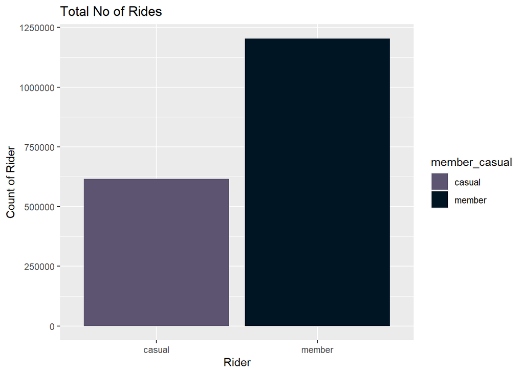

```r
ggplot(data = trip) +
  geom_bar(mapping = aes(x = member_casual, fill = member_casual)) +
  scale_fill_manual(values = c("casual" = "#5C5470", "member" = "#001524")) +
  labs(title = "Total No of Rides", x = "Rider", y = "Count of Rider")
```

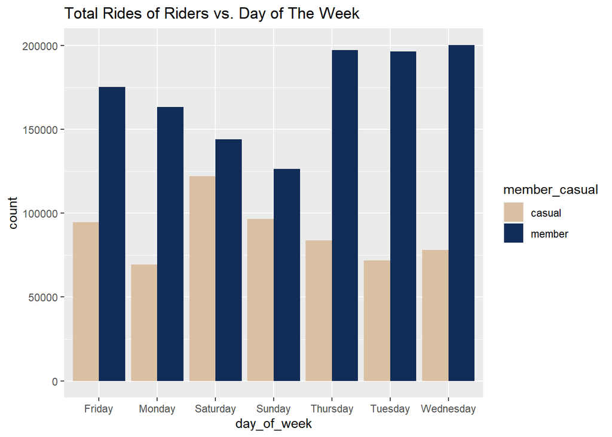

```r
ggplot(data = trip) +
  geom_bar(mapping = aes(x = day_of_week, fill = member_casual), position = "dodge") +
  scale_fill_manual(values = c("casual" = "#DAC0A3", "member" = "#102C57"))+
  labs(title = "Total Rides of Riders vs. Day of The Week")
```

```
## Defaulting to continuous.
```

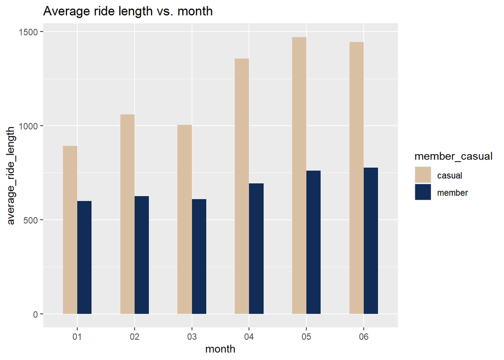

```r
trip %>%
  group_by(member_casual, month) %>%
  summarise(average_ride_length = mean(tripduration), .groups = "drop") %>%
  ggplot(aes(x = month, y = average_ride_length, fill = member_casual)) +
  geom_col(width = 0.5, position = position_dodge(width = 0.5)) +
  scale_fill_manual(values = c("casual" = "#DAC0A3", "member" = "#102C57"))+
  labs(title = "Average ride length vs. month")
```